# Programación básica en R

Felipe Calvo Cepeda

2020

## Importar datos a R

- Conjunto de datos

> Una vez descargados los archivos de datos, vamos a ubicarlos al interior de una carpeta llamada **data** que a su vez crearemos dentro del directorio de nuestro proyecto.

### Paquetes para importar datos

```r
# Instalamos los paquetes
install.packages("tidyverse")
install.packages("readxl")
install.packages("haven")
install.packages("googlesheets")
install.packages("RMySQL")

# Cargamos los paquetes
library("tidyverse")
library("readxl")
library("haven")
library("googlesheets")
library("RMySQL")
```

### Archivos de texto plano (.txt)

```r
read_delim(
  file = "data/Boston_Housing.txt",
  delim = "|",
  locale=locale(decimal_mark = ",")
  ) -> boston_housing_txt

read.table(
  file =  "data/Boston_Housing.txt",
  sep =  "|",
  header = TRUE,
  dec = ",",
  fileEncoding = "UTF-8"
  ) -> boston_housing_txt

str(boston_housing_txt)
```

### Archivo de valores separados por comas (.csv)

```r
read_csv2(
  file = "data/Boston_Housing.csv"
) -> boston_housing_csv

str(boston_housing_csv)
```

### Archivos de Excel (.xls .xlsx)

```r
## library("readxl")
read_excel(
  path = "data/Boston_Housing.xls"
) -> boston_housing_xls

str(boston_housing_xls)

read_xlsx(
  path = "data/Boston_Housing.xlsx",
  sheet="Data"
) -> boston_housing_xlsx
str(boston_housing_xlsx)
```

### Archivos de STATA (.dta)

```r
## library("haven")
read_dta(
  file = "data/Boston_Housing.dta"
) -> boston_housing_dta

str(boston_housing_dta)
```

### Archivos de bases de datos de SPSS

```r
## library("haven")
read_sav(
  file = "data/PRICING.sav"
) -> pricing_sav

str(pricing_sav)
```

### Bases de datos en Google Sheets

```r
# library("googlesheets")
"https://docs.google.com/spreadsheets/d/1z7uEedjNKXN4ub5lNZLO-dJhtWs4-Lv3PRcOTf-HWdk/edit?usp=sharing" -> link
gs_url(link, lookup = FALSE, verbose = FALSE) -> online_gs_object
gs_read(online_gs_object, verbose = FALSE) -> boston_housing_gs

str(boston_housing_gs)
```

> Ya sabemos importar datos.

> Ahora vamos a ver distintos elementos que necesitamos para procesarlos.

## Algoritmos

Un algoritmo es un conjunto finito de instrucciones que, si se siguen rigurosamente, llevan a cabo una tarea específica.

Todos los algoritmos se componen de “partes” básicas que se utilizan para crear “partes” más complejas.

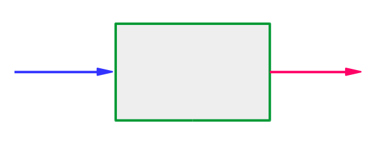

> El **tratamiento, análisis y modelado de datos** lo haremos mediante algoritmos.

## Tipos y operaciones

### Tipos de variables

- Booleanos
  - VERDADERO
  - FALSO
- Numéricos
  - Enteros
  - Reales
- Alfanuméricos: caracteres o cadenas de texto
- Fechas
- NA

### Operadores matemáticos

```r
2+2
```

```
## [1] 4
```

```r
5-2
```

```
## [1] 3
```

```r
3*4
```

```
## [1] 12
```

```r
5/4
```

```
## [1] 1.25
```

```r
9 %% 2
```

```
## [1] 1
```

```r
3 ** 3
```

```
## [1] 27
```

```r
3 ^ 3
```

```
## [1] 27
```

```r
log(10)
```

```
## [1] 2.302585
```

```r
sqrt(16)
```

```
## [1] 4
```

### Operadores para comparación

```r
5 > 2
```

```
## [1] TRUE
```

```r
5 < 2
```

```
## [1] FALSE
```

```r
10 == 10
```

```
## [1] TRUE
```

```r
10 == 9
```

```
## [1] FALSE
```

```r
10 != 9
```

```
## [1] TRUE
```

```r
10 >= 10
```

```
## [1] TRUE
```

```r
10 <= 8
```

```
## [1] FALSE
```

### Operadores lógicas

- Conjunción (se cumplen ambas): &&
- Disyunción (se cumple alguna): ||
- Negación (lo contrario): !

### Orden de las operaciones

- PEMDAS
  - Paréntesis
  - Exponentes
  - Multiplicaciones / Divisiones
  - Adición / Sustracción

## Variables

```r
pi = 3.1415
radio = 3
area = pi * radio**2
area
```

```
## [1] 28.2735
```

```r
round(area, 2)
```

```
## [1] 28.27
```

## Vectores, factores, matrices, arreglos y tablas

- Vectores: Arreglos lineales del mismo tipo. Tienen de la misma clase.
- Factores: Arreglos lineales numéricos enmascarados como caracteres. Si no los conoces bien mejor no usarlos.
- Matrices: Arreglos rectangulares del mismo tipo. Sábanas de la misma clase.
- Arreglos: Organizaciones cúbicas y de mayor dimensión.
- Tablas: La estructura data.frame permite tener tablas de datos, donde cada columna es de un tipo determinado, pero no todas iguales.

### Vectores

```r
1:5
```

```
## [1] 1 2 3 4 5
```

```r
letters
```

```
##  [1] "a" "b" "c" "d" "e" "f" "g" "h" "i" "j" "k" "l" "m" "n" "o" "p" "q"
## [18] "r" "s" "t" "u" "v" "w" "x" "y" "z"
```

```r
LETTERS
```

```
##  [1] "A" "B" "C" "D" "E" "F" "G" "H" "I" "J" "K" "L" "M" "N" "O" "P" "Q"
## [18] "R" "S" "T" "U" "V" "W" "X" "Y" "Z"
```

```r
c(1, 3, 2, 15, 4, 0, 0, 0, 1)
```

```
## [1]  1  3  2 15  4  0  0  0  1
```

```r
seq(10, 100)
```

```
##  [1]  10  11  12  13  14  15  16  17  18  19  20  21  22  23  24  25  26
## [18]  27  28  29  30  31  32  33  34  35  36  37  38  39  40  41  42  43
## [35]  44  45  46  47  48  49  50  51  52  53  54  55  56  57  58  59  60
## [52]  61  62  63  64  65  66  67  68  69  70  71  72  73  74  75  76  77
## [69]  78  79  80  81  82  83  84  85  86  87  88  89  90  91  92  93  94
## [86]  95  96  97  98  99 100
```

```r
seq(10, 100, by = 5)
```

```
##  [1]  10  15  20  25  30  35  40  45  50  55  60  65  70  75  80  85  90
## [18]  95 100
```

```r
seq(10, 100, length.out = 8)
```

```
## [1]  10.00000  22.85714  35.71429  48.57143  61.42857  74.28571  87.14286
## [8] 100.00000
```

### Factores

```r
as.factor(letters)
```

```
##  [1] a b c d e f g h i j k l m n o p q r s t u v w x y z
## Levels: a b c d e f g h i j k l m n o p q r s t u v w x y z
```

### Funciones sobre vectores

```r
vector_logico <- c(TRUE,FALSE,FALSE,TRUE,FALSE)
vector_cualquiera <- seq(1, 100, by = 3)
un_vector <- c(1, 2, 3, 4, 5)
otro_vector <- c(6, 7, 8, 9, 10)
which(vector_logico) # me dice cuales son los verdaderos
```

```
## [1] 1 4
```

```r
length(vector_cualquiera) # me dice cuánto mide el vector
```

```
## [1] 34
```

```r
c(un_vector, otro_vector) # concatena los vectores
```

```
##  [1]  1  2  3  4  5  6  7  8  9 10
```

### Operaciones entre vectores

```r
vector_numerico <- c(2, 4, 6, 8, 10)
vector_numeric_1 <- 1:3
vector_numeric_2 <- 3:5
vector_numerico > 3
```

```
## [1] FALSE  TRUE  TRUE  TRUE  TRUE
```

```r
1:5 %in% 3:8
```

```
## [1] FALSE FALSE  TRUE  TRUE  TRUE
```

```r
outer(vector_numeric_1, vector_numeric_2, "*")
```

```
##      [,1] [,2] [,3]
## [1,]    3    4    5
## [2,]    6    8   10
## [3,]    9   12   15
```

```r
outer(vector_numeric_1, vector_numeric_2, ">")
```

```
##       [,1]  [,2]  [,3]
## [1,] FALSE FALSE FALSE
## [2,] FALSE FALSE FALSE
## [3,] FALSE FALSE FALSE
```

### Operaciones entre vectores (conjuntos)

```r
union(vector_numeric_1, vector_numeric_2)
```

```
## [1] 1 2 3 4 5
```

```r
intersect(vector_numeric_1, vector_numeric_2)
```

```
## [1] 3
```

```r
setdiff(vector_numeric_1, vector_numeric_2)
```

```
## [1] 1 2
```

### Matrices

```r
matrix(data = 1:12, nrow = 3)
```

```
##      [,1] [,2] [,3] [,4]
## [1,]    1    4    7   10
## [2,]    2    5    8   11
## [3,]    3    6    9   12
```

```r
matrix(data = 1:12, nrow = 6)
```

```
##      [,1] [,2]
## [1,]    1    7
## [2,]    2    8
## [3,]    3    9
## [4,]    4   10
## [5,]    5   11
## [6,]    6   12
```

```r
matrix(data = 1:12, ncol = 6)
```

```
##      [,1] [,2] [,3] [,4] [,5] [,6]
## [1,]    1    3    5    7    9   11
## [2,]    2    4    6    8   10   12
```

```r
matrix(data = 1:12, nrow = 4)
```

```
##      [,1] [,2] [,3]
## [1,]    1    5    9
## [2,]    2    6   10
## [3,]    3    7   11
## [4,]    4    8   12
```

```r
matrix(data = 1:12, nrow = 4, byrow = TRUE)
```

```
##      [,1] [,2] [,3]
## [1,]    1    2    3
## [2,]    4    5    6
## [3,]    7    8    9
## [4,]   10   11   12
```

```r
matrix(data = seq(0, 9, length.out = 4), nrow = 2) -> mi_matriz
mi_matriz
```

```
##      [,1] [,2]
## [1,]    0    6
## [2,]    3    9
```

### Operaciones sobre matrices

```r
otra_matriz # Toca inventársela
mi_matriz*2
mi_matriz + otra_matriz
mi_matriz*otra_matriz # Producto celda por celda
mi_matriz %*% otra_matriz # Producto de matrices
```

### Funciones sobre matrices

```r
t(mi_matriz) #mi_matriz transpuesta
```

```
##      [,1] [,2]
## [1,]    0    3
## [2,]    6    9
```

```r
diag(mi_matriz) #Diagonal de mi_matriz
```

```
## [1] 0 9
```

```r
det(mi_matriz) # Determinante, debe dar un número
```

```
## [1] -18
```

```r
solve(mi_matriz) # Matriz inversa, sólo se puede con matrices cuadradas de determinante distinto de cero
```

```
##            [,1]      [,2]
## [1,] -0.5000000 0.3333333
## [2,]  0.1666667 0.0000000
```

```r
dim(mi_matriz) # Dimensión de mi matriz
```

```
## [1] 2 2
```

### Tablas

```r
iris
diamonds
mpg

class(diamonds)
class(mpg)

str(diamonds)
str(mpg)
```